# Diamonds quality

Filippo Pilutti

2026-11-09

In this data challenge we explore the qualities of diamonds and their association with price using the `ggplot2::diamonds` dataset:

1. First of all, observe that low quality diamonds (with respect to cut, color and clarity) are more expensive.
2. Using models, find an explanation and solve the apparent paradox.

Recall that:

- best cut is Ideal, worst is Fair
- best color is D, worst is J
- best clarity is IF, worst is I1

### 1. First of all, observe that low quality diamonds (with respect to cut, color and clarity) are more expensive.

We start by observing the data.

```r
diamonds
```

```
## # A tibble: 53,940 × 10
##    carat cut       color clarity depth table price     x     y     z
##    <dbl> <ord>     <ord> <ord>   <dbl> <dbl> <int> <dbl> <dbl> <dbl>
##  1  0.23 Ideal     E     SI2      61.5    55   326  3.95  3.98  2.43
##  2  0.21 Premium   E     SI1      59.8    61   326  3.89  3.84  2.31
##  3  0.23 Good      E     VS1      56.9    65   327  4.05  4.07  2.31
##  4  0.29 Premium   I     VS2      62.4    58   334  4.2   4.23  2.63
##  5  0.31 Good      J     SI2      63.3    58   335  4.34  4.35  2.75
##  6  0.24 Very Good J     VVS2     62.8    57   336  3.94  3.96  2.48
##  7  0.24 Very Good I     VVS1     62.3    57   336  3.95  3.98  2.47
##  8  0.26 Very Good H     SI1      61.9    55   337  4.07  4.11  2.53
##  9  0.22 Fair      E     VS2      65.1    61   337  3.87  3.78  2.49
## 10  0.23 Very Good H     VS1      59.4    61   338  4     4.05  2.39
## # ℹ 53,930 more rows
```

```r
levels(diamonds$cut)
```

```
## [1] "Fair"      "Good"      "Very Good" "Premium"   "Ideal"
```

```r
levels(diamonds$color)
```

```
## [1] "D" "E" "F" "G" "H" "I" "J"
```

```r
levels(diamonds$clarity)
```

```
## [1] "I1"   "SI2"  "SI1"  "VS2"  "VS1"  "VVS2" "VVS1" "IF"
```

We choose to visualize the data using boxplots, plotting the price against each cut, color and clarity. Boxplots show median and quartiles, allowing us to visualize the prices distribution along the different levels of each category.

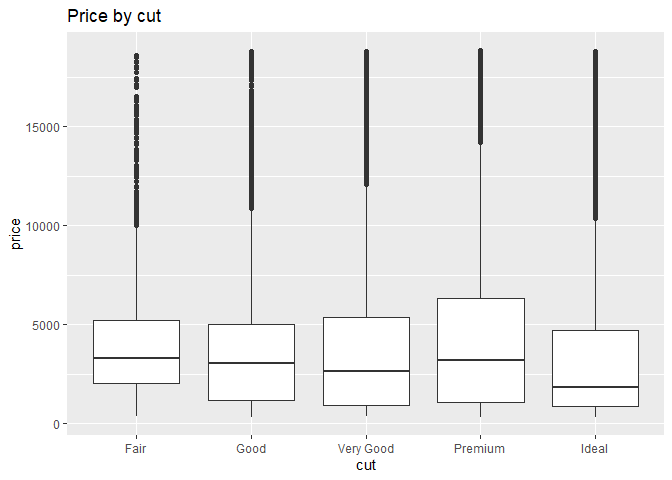

```r
# Price distribution by cut
ggplot(diamonds, aes(cut, price)) +
  geom_boxplot() +
  labs(title = "Price by cut")
```

```r
# Median price for each level of cut
diamonds |>
  group_by(cut) |>
  summarise(n = n(), median_price = median(price))
```

```
## # A tibble: 5 × 3
##   cut           n median_price
##   <ord>     <int>        <dbl>
## 1 Fair       1610        3282
## 2 Good       4906        3050.
## 3 Very Good 12082        2648
## 4 Premium   13791        3185
## 5 Ideal     21551        1810
```

`Cut`: the best category (Ideal) has the lowest median price, while Fair (the worst one) has the highest one

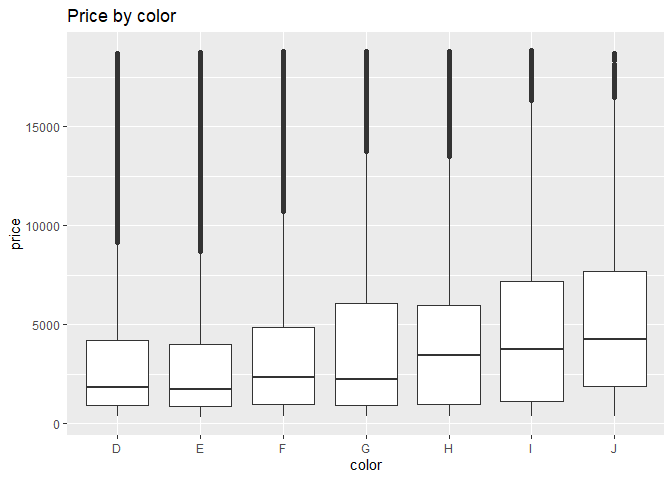

```r
# Price distribution by color
ggplot(diamonds, aes(color, price)) +
  geom_boxplot() +
  labs(title = "Price by color")
```

```r
# Median price for each level of color
diamonds |>
  group_by(color) |>
  summarise(n = n(), median_price = median(price))
```

```
## # A tibble: 7 × 3
##   color     n median_price
##   <ord> <int>        <dbl>
## 1 D      6775        1838
## 2 E      9797        1739
## 3 F      9542        2344.
## 4 G     11292        2242
## 5 H      8304        3460
## 6 I      5422        3730
## 7 J      2808        4234
```

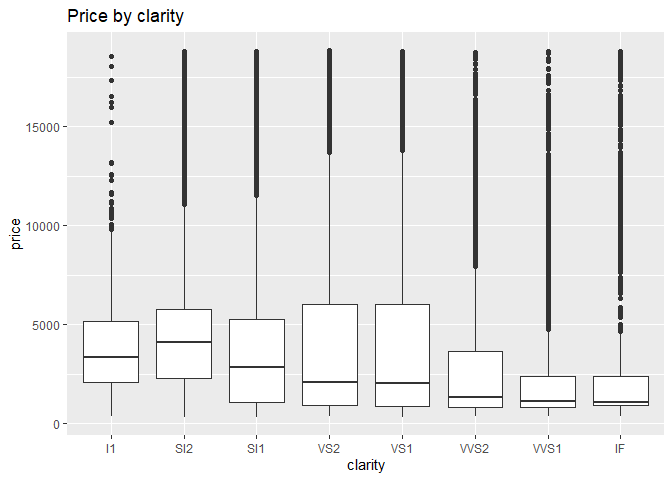

```r
# Price distribution by clarity
ggplot(diamonds, aes(clarity, price)) +
  geom_boxplot() +
  labs(title = "Price by clarity")
```

```r
# Median price for each level of clarity
diamonds |>
  group_by(clarity) |>
  summarise(n = n(), median_price = median(price))
```

```
## # A tibble: 8 × 3
##   clarity     n median_price
##   <ord>   <int>        <dbl>
## 1 I1        741         3344
## 2 SI2      9194         4072
## 3 SI1     13065         2822
## 4 VS2     12258         2054
## 5 VS1      8171         2005
## 6 VVS2     5066         1311
## 7 VVS1     3655         1093
## 8 IF       1790         1080
```

`Clarity`: the two worst classes (I1, SI2) have the highest median prices, the best classes (VVS1, IF) have the lowest ones.

The data shows that higher quality diamonds appear to be cheaper: the trend is clear for `color` and `clarity`, and less regular (but still visible) for `cut`.

### 2. Using models, find an explanation and solve the apparent paradox.

We think that there is another variable, influencing both the quality and the price of each diamond, and causing this apparent paradox. We suppose that this variable is `carat`, and we want to show that.

First, we want to observe the `carat` variable.

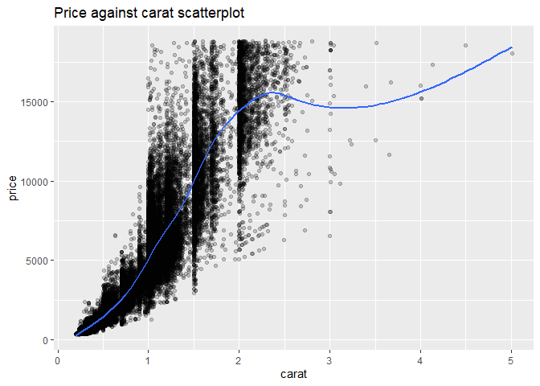

```r
# Scatter plot of price against carat
diamonds |>
  ggplot(aes(carat, price)) +
  geom_point(alpha = 0.2) +
  geom_smooth(se = FALSE) +
  labs(title = "Price against carat scatterplot")
```

```r
# Strength of the association
cor(diamonds$carat, diamonds$price, method = "pearson")
```

```
## [1] 0.9215913
```

```r
cor(diamonds$carat, diamonds$price, method = "spearman")
```

```
## [1] 0.9628828
```

We see a strong positive association (Pearson ca. 0.92). The relationship is non-linear: price increases more than proportionally with weight, with a larger spread for heavier diamonds. We can also notice concentrations (vertical lines) around round carat values (0.5, 1, 1.5, 2), likely reflecting buyers’ psychological preferences.

Let’s now observe how carat weight relates to other quality variables.

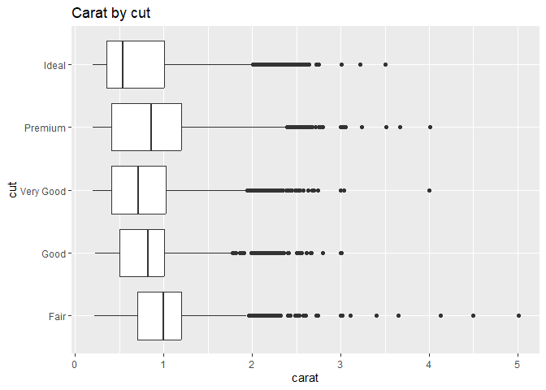

```r
# Carat distribution by cut level
ggplot(diamonds, aes(carat, cut)) +
  geom_boxplot() +
  labs(title = "Carat by cut")
```

```r
# Median carat and median price for each level of cut
diamonds |>
  group_by(cut) |>
  summarise(
    n = n(),
    median_carat = median(carat),
    median_price = median(price)
  )
```

```
## # A tibble: 5 × 4
##   cut           n median_carat median_price
##   <ord>     <int>        <dbl>        <dbl>
## 1 Fair       1610         1           3282
## 2 Good       4906         0.82        3050.
## 3 Very Good 12082         0.71        2648
## 4 Premium   13791         0.86        3185
## 5 Ideal     21551         0.54        1810
```

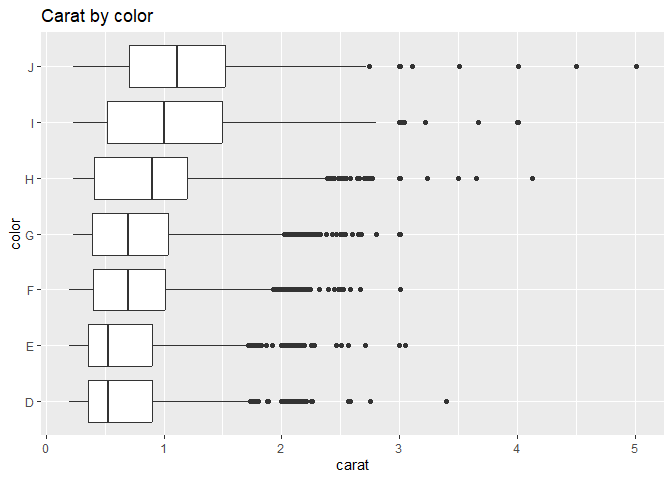

```r
# Carat distribution by color level
ggplot(diamonds, aes(carat, color)) +
  geom_boxplot() +
  labs(title = "Carat by color")
```

```r
# Median carat and median price for each level of color
diamonds |>
  group_by(color) |>
  summarise(
    n = n(),
    median_carat = median(carat),
    median_price = median(price)
  )
```

```
## # A tibble: 7 × 4
##   color     n median_carat median_price
##   <ord> <int>        <dbl>        <dbl>
## 1 D      6775         0.53        1838
## 2 E      9797         0.53        1739
## 3 F      9542         0.7         2344.
## 4 G     11292         0.7         2242
## 5 H      8304         0.9         3460
## 6 I      5422         1           3730
## 7 J      2808         1.11        4234
```

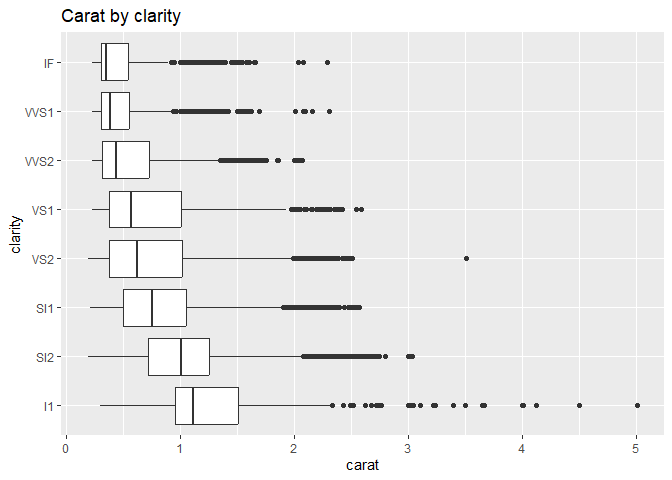

```r
# Carat distribution by clarity level
ggplot(diamonds, aes(carat, clarity)) +
  geom_boxplot() +
  labs(title = "Carat by clarity")
```

```r
# Median carat and median price for each level of clarity
diamonds |>
  group_by(clarity) |>
  summarise(
    n = n(),
    median_carat = median(carat),
    median_price = median(price)
  )
```

```
## # A tibble: 8 × 4
##   clarity     n median_carat median_price
##   <ord>   <int>        <dbl>        <dbl>
## 1 I1        741         1.12         3344
## 2 SI2      9194         1.01         4072
## 3 SI1     13065         0.76         2822
## 4 VS2     12258         0.63         2054
## 5 VS1      8171         0.57         2005
## 6 VVS2     5066         0.44         1311
## 7 VVS1     3655         0.39         1093
## 8 IF       1790         0.35         1080
```

We observe that the medians of `carat` follow the same trend of those of `price`, in all the quality variables. This shows that lower quality diamonds tend to be heavier, and suggests that their higher weight raises their price more than their lower quality reduces it. We verify this hypothesis with a model.

We want to fit a model between carat and price, so let’s try a linear one.

```r
mod_carat <- lm(price ~ carat, data = diamonds)

summary(mod_carat)
```

```
##
## Call:
## lm(formula = price ~ carat, data = diamonds)
##
## Residuals:
##      Min       1Q   Median       3Q      Max
## -18585.3   -804.8    -18.9    537.4  12731.7
##
## Coefficients:
##             Estimate Std. Error t value Pr(>|t|)
## (Intercept) -2256.36      13.06  -172.8   <2e-16 ***
## carat        7756.43      14.07   551.4   <2e-16 ***
## ---
## Signif. codes:  0 '***' 0.001 '**' 0.01 '*' 0.05 '.' 0.1 ' ' 1
##
## Residual standard error: 1549 on 53938 degrees of freedom
## Multiple R-squared:  0.8493, Adjusted R-squared:  0.8493
## F-statistic: 3.041e+05 on 1 and 53938 DF,  p-value: < 2.2e-16
```

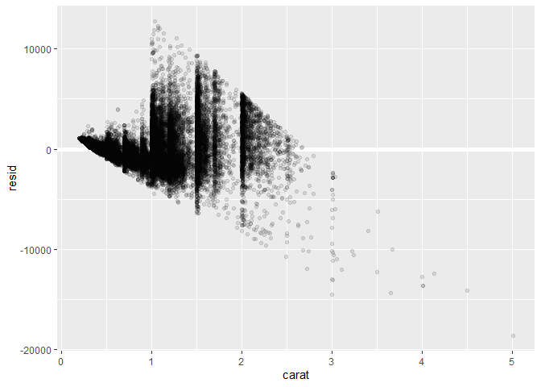

```r
# Add residuals to the data
diamonds2 <- add_residuals(diamonds, mod_carat) |>
  select(carat, cut, color, clarity, price, resid)

# Scatterplot of residuals against carat
ggplot(diamonds2, aes(carat, resid)) +
  geom_ref_line(h = 0) +
  geom_point(alpha = 0.1)
```

The residuals of the linear model still show a clear pattern with respect to carat: the relationship between carat and price is not linear, so the model does not fully capture the effect of weight.

To fix this, we use the same model, but we transform the variables using the logarithm.

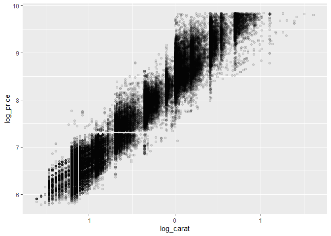

```r
diamonds2 <- diamonds2 |>
  mutate(log_price = log(price), log_carat = log(carat))

# Scatter plot on the log scale
ggplot(diamonds2, aes(log_carat, log_price)) +
  geom_point(alpha = 0.1)
```

```r
# Linear model with log scale
mod_log <- lm(log_price ~ log_carat, data = diamonds2)
summary(mod_log)
```

```
##
## Call:
## lm(formula = log_price ~ log_carat, data = diamonds2)
##
## Residuals:
##      Min       1Q   Median       3Q      Max
## -1.50833 -0.16951 -0.00591  0.16637  1.33793
##
## Coefficients:
##             Estimate Std. Error t value Pr(>|t|)
## (Intercept) 8.448661   0.001365  6190.9   <2e-16 ***
## log_carat   1.675817   0.001934   866.6   <2e-16 ***
## ---
## Signif. codes:  0 '***' 0.001 '**' 0.01 '*' 0.05 '.' 0.1 ' ' 1
##
## Residual standard error: 0.2627 on 53938 degrees of freedom
## Multiple R-squared:  0.933,  Adjusted R-squared:  0.933
## F-statistic: 7.51e+05 on 1 and 53938 DF,  p-value: < 2.2e-16
```

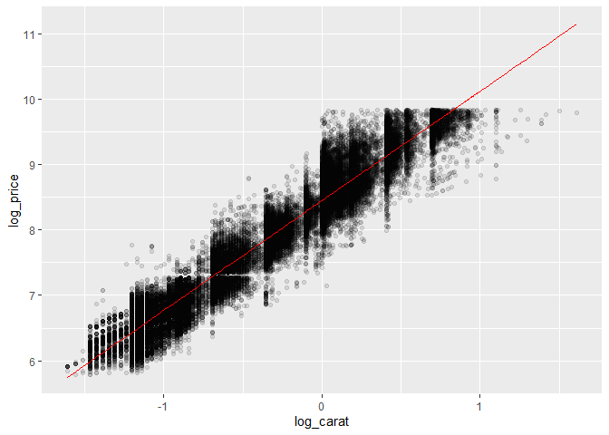

```r
# Model visualization
grid <- data_grid(diamonds2, log_carat)
grid <- add_predictions(grid, mod_log)

ggplot(diamonds2, aes(x = log_carat)) +
  geom_point(aes(y = log_price), alpha = 0.1) +
  geom_line(data = grid, mapping = aes(y = pred), color = "red")
```

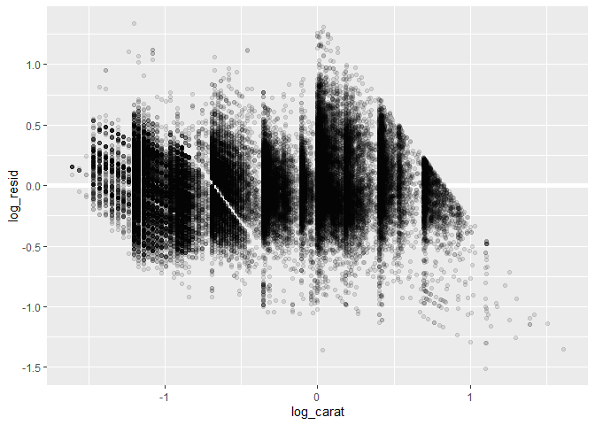

```r
# We add residuals of the log model
diamonds2 <- add_residuals(diamonds2, mod_log, var = "log_resid")

ggplot(diamonds2, aes(log_carat, log_resid)) +
  geom_ref_line(h = 0) +
  geom_point(alpha = 0.1)
```

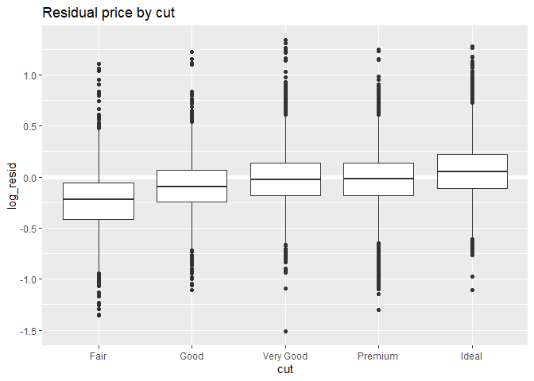

```r
ggplot(diamonds2, aes(cut, log_resid)) +
  geom_ref_line(h = 0) +
  geom_boxplot() +
  labs(title = "Residual price by cut")
```

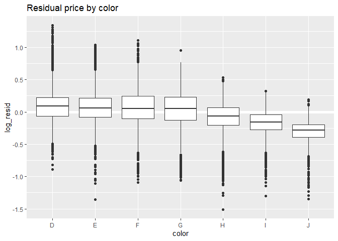

```r
ggplot(diamonds2, aes(color, log_resid)) +
  geom_ref_line(h = 0) +
  geom_boxplot() +
  labs(title = "Residual price by color")
```

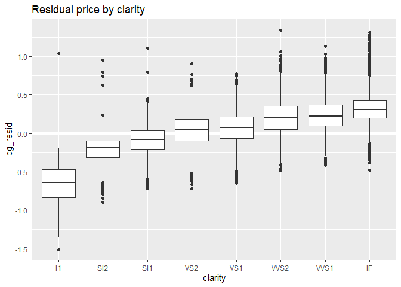

```r
ggplot(diamonds2, aes(clarity, log_resid)) +
  geom_ref_line(h = 0) +
  geom_boxplot() +
  labs(title = "Residual price by clarity")
```

Once the effect of weight is removed, the relationship between quality and price is the expected one: for the same carat, better cut, color and clarity correspond to higher prices. The apparent paradox is explained by carat: low quality diamonds tend to be heavier, and weight is the most important factor in determining price.